# Elsevier 2022 SDG mapping

# General to all SDGs

## Introduction

The United Nations Sustainable Development Goals (SDGs) challenge the global community to build a world where no one is left behind.

Since 2018, Elsevier has generated SDG search queries to help researchers and institutions track and demonstrate progress toward the SDG targets. In the past 3 years, these queries, along with the university’s own data and evidence supporting progress and contributions to the particular SDG outside of research-based metrics, are used for the THE Impact Rankings.

## Method

For 2022, this SDG uses the exact same search query and ML algorithm as the Elsevier 2021 SDG mapping. [Full details of the 2021 methodology are available on Digital Commons Data.](https://elsevier.digitalcommonsdata.com/datasets/9sxdykm8s4/4)

# [SDG 1 - End poverty in all its forms everywhere](https://sdgs.un.org/goals/goal1)

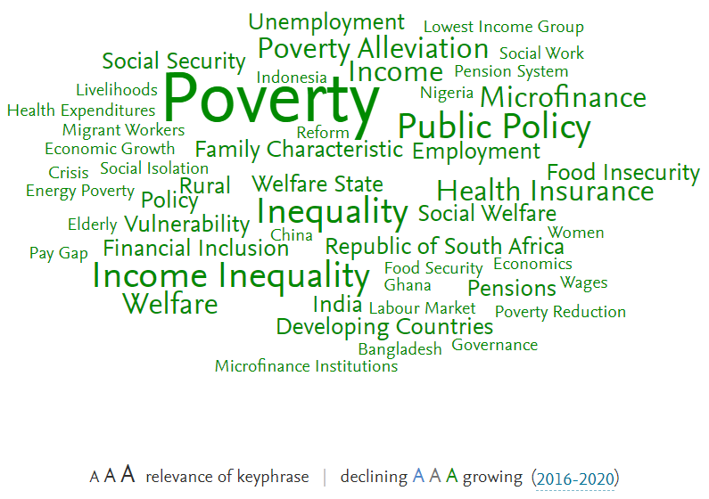

Explore this wordcloud plus the most active contributors on the [SciVal SDG site](https://scival.com/sdg)

## Query

Below is the full search query used for SDG 1. We’ve broken it down by each query component. Use the + and – to concatenate the different bracket levels.

(

(

(

(

TITLE-ABS("unesco") AND TITLE-ABS("poverty") AND TITLE-ABS("program")

)

OR

(

AUTHKEY("unesco") AND AUTHKEY("poverty") AND AUTHKEY("program")

)

OR

(

TITLE-ABS("poverty*-reducing* polic*") OR TITLE-ABS("povertyreducing* polic*")

)

OR

(

AUTHKEY("poverty*-reducing* polic*") OR AUTHKEY("povertyreducing* polic*")

)

OR

(

TITLE-ABS("foreign aid") AND TITLE-ABS("poverty")

)

OR

(

AUTHKEY("foreign aid") AND AUTHKEY("poverty")

)

OR

(

TITLE-ABS("united nations") AND TITLE-ABS("poverty") AND TITLE-ABS("program")

)

OR

(

AUTHKEY("united nations") AND AUTHKEY("poverty") AND AUTHKEY("program")

)

OR

(

TITLE-ABS("international aid") AND TITLE-ABS("poverty")

)

OR

(

AUTHKEY("international aid") AND AUTHKEY("poverty")

)

OR

(

TITLE-ABS("world bank") AND TITLE-ABS("poverty")

)

OR

(

AUTHKEY("world bank") AND AUTHKEY("poverty")

)

OR

(

TITLE-ABS("humanitarian* assist*") AND TITLE-ABS("poverty")

)

OR

(

AUTHKEY("humanitarian* assist*") AND AUTHKEY("poverty")

)

OR

(

TITLE-ABS("international support") AND TITLE-ABS("poverty")

)

OR

(

AUTHKEY("international support") AND AUTHKEY("poverty")

)

OR

(

TITLE-ABS("gender* inequit*") AND (TITLE-ABS("policy") OR TITLE-ABS("policies"))

)

OR

(

AUTHKEY("gender* inequit*") AND (AUTHKEY("policy") OR AUTHKEY("policies"))

)

OR

(

TITLE-ABS("humanitarian aid") AND TITLE-ABS("poverty")

)

OR

(

AUTHKEY("humanitarian aid") AND AUTHKEY("poverty")

)

OR

(

TITLE-ABS("NGOs") AND TITLE-ABS("poverty")

)

OR

(

AUTHKEY("NGOs") AND AUTHKEY("poverty")

)

OR

(

TITLE-ABS("unicef") AND TITLE-ABS("poverty") AND TITLE-ABS("program")

)

OR

(

AUTHKEY("unicef") AND AUTHKEY("poverty") AND AUTHKEY("program")

)

OR

(

TITLE-ABS("international program") AND TITLE-ABS("poverty")

)

OR

(

AUTHKEY("international program") AND AUTHKEY("poverty")

)

OR

(

TITLE-ABS("food bank") OR TITLE-ABS("food banks")

)

OR

(

AUTHKEY("food bank") OR AUTHKEY("food banks")

)

OR

(

TITLE-ABS("Development* strateg*") AND (TITLE-ABS("poverty") OR TITLE-ABS("developing* countr*"))

)

OR

(

AUTHKEY("Development* strateg*") AND (AUTHKEY("poverty") OR AUTHKEY("developing* countr*"))

)

OR

(

TITLE-ABS("international support") AND TITLE-ABS("poverty")

)

OR

(

AUTHKEY("international support") AND AUTHKEY("poverty")

)

OR

(

TITLE-ABS("international development") AND TITLE-ABS("poverty")

)

OR

(

AUTHKEY("international development") AND AUTHKEY("poverty")

)

OR

(

TITLE-ABS("gender* inequit*") AND (TITLE-ABS("strategy") OR TITLE-ABS("strategies"))

)

OR

(

AUTHKEY("gender* inequit*") AND (AUTHKEY("strategy") OR AUTHKEY("strategies"))

)

OR

(

TITLE-ABS("international* mobili*") AND TITLE-ABS("poverty")

)

OR

(

AUTHKEY("international* mobili*") AND AUTHKEY("poverty")

)

OR

(

(TITLE-ABS("pro-poor") AND (TITLE-ABS("policy") OR TITLE-ABS("policies"))) OR (TITLE-ABS("propoor") AND (TITLE-ABS("policy") OR TITLE-ABS("policies")))

)

OR

(

(AUTHKEY("pro-poor") AND (AUTHKEY("policy") OR AUTHKEY("policies"))) OR (AUTHKEY("propoor") AND (AUTHKEY("policy") OR AUTHKEY("policies")))

)

OR

(

TITLE-ABS("international cooperation") AND TITLE-ABS("poverty")

)

OR

(

AUTHKEY("international cooperation") AND AUTHKEY("poverty")

)

OR

(

(TITLE-ABS("policy") OR TITLE-ABS("policies")) AND TITLE-ABS("poverty")

)

OR

(

(AUTHKEY("policy") OR AUTHKEY("policies")) AND AUTHKEY("poverty")

)

OR

(

TITLE-ABS("development aid") AND TITLE-ABS("poverty")

)

OR

(

AUTHKEY("development aid") AND AUTHKEY("poverty")

)

OR

(

(TITLE-ABS("pro-poor") AND (TITLE-ABS("strategy") OR TITLE-ABS("strategies"))) OR (TITLE-ABS("propoor") AND (TITLE-ABS("strategy") OR TITLE-ABS("strategies")))

)

OR

(

(AUTHKEY("pro-poor") AND (AUTHKEY("strategy") OR AUTHKEY("strategies"))) OR (AUTHKEY("propoor") AND (AUTHKEY("strategy") OR AUTHKEY("strategies")))

)

)

AND NOT

(

(

TITLE-ABS("natural disaster") OR AUTHKEY("natural disaster") OR TITLE-ABS("family planning") OR AUTHKEY("family planning") OR TITLE-ABS("climate change") OR AUTHKEY("climate change") OR TITLE-ABS("fuel poverty") OR AUTHKEY("fuel poverty") OR TITLE-ABS("energy poverty") OR AUTHKEY("energy poverty") OR ((TITLE-ABS("outer space") OR TITLE-ABS("outer-space")) OR (TITLE-ABS("outer space") OR TITLE-ABS("outerspace"))) OR ((AUTHKEY("outer space") OR AUTHKEY("outer-space")) OR (AUTHKEY("outer space") OR AUTHKEY("outerspace"))) OR TITLE-ABS("diagnosis") OR AUTHKEY("diagnosis") OR TITLE-ABS("diabetic* patient*") OR AUTHKEY("diabetic* patient*") OR TITLE-ABS("parental leave") OR AUTHKEY("parental leave") OR (TITLE-ABS("schizophrenia") AND TITLE-ABS("treatment")) OR (AUTHKEY("schizophrenia") AND AUTHKEY("treatment")) OR TITLE-ABS("diabetic* patient*") OR AUTHKEY("diabetic* patient*")

)

)

)

)

OR

(

(

(

(

((TITLE("provision of drinking water") OR TITLE("sanitation")) AND (TITLE("low-income") OR TITLE("poverty") OR TITLE("poor people") OR TITLE("poorer people") OR TITLE("rural poor") OR TITLE("rural* communit*") OR TITLE("urban* dweller*") OR TITLE("ghettos"))) OR ((TITLE("provision of drinking water") OR TITLE("sanitation")) AND (TITLE("lowincome") OR TITLE("poverty") OR TITLE("poor people") OR TITLE("poorer people") OR TITLE("rural poor") OR TITLE("rural* communit*") OR TITLE("urban* dweller*") OR TITLE("ghettos")))

)

OR

(

((AUTHKEY("provision of drinking water") OR AUTHKEY("sanitation")) AND (AUTHKEY("low-income") OR AUTHKEY("poverty") OR AUTHKEY("poor people") OR AUTHKEY("poorer people") OR AUTHKEY("rural poor") OR AUTHKEY("rural* communit*") OR AUTHKEY("urban* dweller*") OR AUTHKEY("ghettos"))) OR ((AUTHKEY("provision of drinking water") OR AUTHKEY("sanitation")) AND (AUTHKEY("lowincome") OR AUTHKEY("poverty") OR AUTHKEY("poor people") OR AUTHKEY("poorer people") OR AUTHKEY("rural poor") OR AUTHKEY("rural* communit*") OR AUTHKEY("urban* dweller*") OR AUTHKEY("ghettos")))

)

OR

(

(TITLE("inequitit*") OR TITLE("inequalit*")) AND (TITLE("income") OR TITLE("earning*"))

)

OR

(

(AUTHKEY("inequitit*") OR AUTHKEY("inequalit*")) AND (AUTHKEY("income") OR AUTHKEY("earning*"))

)

OR

(

TITLE("wage") AND TITLE("inequalit*")

)

OR

(

AUTHKEY("wage") AND AUTHKEY("inequalit*")

)

OR TITLE-ABS

(

"asset poverty"

)

OR AUTHKEY

(

"asset poverty"

)

OR

(

TITLE-ABS("social exclusion") AND (TITLE-ABS("poverty") OR TITLE-ABS("the poor") OR TITLE-ABS("poor people") OR TITLE-ABS("developing* countr*") OR TITLE-ABS("poor* communit*") OR TITLE-ABS("rights") OR TITLE-ABS("racial") OR TITLE-ABS("racism") OR TITLE-ABS("women"))

)

OR

(

AUTHKEY("social exclusion") AND (AUTHKEY("poverty") OR AUTHKEY("the poor") OR AUTHKEY("poor people") OR AUTHKEY("developing* countr*") OR AUTHKEY("poor* communit*") OR AUTHKEY("rights") OR AUTHKEY("racial") OR AUTHKEY("racism") OR AUTHKEY("women"))

)

OR

(

(TITLE-ABS("asset*-poor* household*") OR TITLE-ABS("asset*-poor* famil*")) OR (TITLE-ABS("assetpoor* household*") OR TITLE-ABS("assetpoor* famil*"))

)

OR

(

(AUTHKEY("asset*-poor* household*") OR AUTHKEY("asset*-poor* famil*")) OR (AUTHKEY("assetpoor* household*") OR AUTHKEY("assetpoor* famil*"))

)

OR

(

(TITLE-ABS("racial* inequalit*") AND (TITLE-ABS("low-income") OR TITLE-ABS("poverty") OR TITLE-ABS("rural poor") OR TITLE-ABS("poor people") OR TITLE-ABS("poorer people") OR TITLE-ABS("developing* countr*") OR TITLE-ABS("aboriginal") OR TITLE-ABS("migrant*") OR TITLE-ABS("refugee") OR TITLE-ABS("indigenous"))) OR (TITLE-ABS("racial* inequalit*") AND (TITLE-ABS("lowincome") OR TITLE-ABS("poverty") OR TITLE-ABS("rural poor") OR TITLE-ABS("poor people") OR TITLE-ABS("poorer people") OR TITLE-ABS("developing* countr*") OR TITLE-ABS("aboriginal") OR TITLE-ABS("migrant*") OR TITLE-ABS("refugee") OR TITLE-ABS("indigenous")))

)

OR

(

(AUTHKEY("racial* inequalit*") AND (AUTHKEY("low-income") OR AUTHKEY("poverty") OR AUTHKEY("rural poor") OR AUTHKEY("poor people") OR AUTHKEY("poorer people") OR AUTHKEY("developing* countr*") OR AUTHKEY("aboriginal") OR AUTHKEY("migrant*") OR AUTHKEY("refugee") OR AUTHKEY("indigenous"))) OR (AUTHKEY("racial* inequalit*") AND (AUTHKEY("lowincome") OR AUTHKEY("poverty") OR AUTHKEY("rural poor") OR AUTHKEY("poor people") OR AUTHKEY("poorer people") OR AUTHKEY("developing* countr*") OR AUTHKEY("aboriginal") OR AUTHKEY("migrant*") OR AUTHKEY("refugee") OR AUTHKEY("indigenous")))

)

OR

(

TITLE-ABS("grameen bank") AND TITLE-ABS("poor")

)

OR

(

AUTHKEY("grameen bank") AND AUTHKEY("poor")

)

OR

(

TITLE-ABS("women") AND TITLE-ABS("access to credit")

)

OR

(

AUTHKEY("women") AND AUTHKEY("access to credit")

)

OR TITLE-ABS

(

"income stratification"

)

OR AUTHKEY

(

"income stratification"

)

OR

(

(TITLE-ABS("micro*-credit*") OR TITLE-ABS("microcredit*") OR TITLE-ABS("micro* credit*")) OR (TITLE-ABS("microcredit*") OR TITLE-ABS("microcredit*") OR TITLE-ABS("micro* credit*"))

)

OR

(

(AUTHKEY("micro*-credit*") OR AUTHKEY("microcredit*") OR AUTHKEY("micro* credit*")) OR (AUTHKEY("microcredit*") OR AUTHKEY("microcredit*") OR AUTHKEY("micro* credit*"))

)

OR

(

(TITLE-ABS("property-rights") AND TITLE-ABS("poverty")) OR (TITLE-ABS("propertyrights") AND TITLE-ABS("poverty"))

)

OR

(

(AUTHKEY("property-rights") AND AUTHKEY("poverty")) OR (AUTHKEY("propertyrights") AND AUTHKEY("poverty"))

)

OR

(

TITLE-ABS("property* right*") AND TITLE-ABS("poverty")

)

OR

(

AUTHKEY("property* right*") AND AUTHKEY("poverty")

)

OR

(

TITLE-ABS("financial barriers") AND (TITLE-ABS("poverty") OR TITLE-ABS("the poor") OR TITLE-ABS("poor people") OR TITLE-ABS("developing* countr*"))

)

OR

(

AUTHKEY("financial barriers") AND (AUTHKEY("poverty") OR AUTHKEY("the poor") OR AUTHKEY("poor people") OR AUTHKEY("developing* countr*"))

)

OR

(

TITLE-ABS("water") AND TITLE-ABS("access") AND (TITLE-ABS("poverty") OR TITLE-ABS("rural") OR TITLE-ABS("the poor") OR TITLE-ABS("poor people") OR TITLE-ABS("developing* countr*") OR TITLE-ABS("rights"))

)

OR

(

AUTHKEY("water") AND AUTHKEY("access") AND (AUTHKEY("poverty") OR AUTHKEY("rural") OR AUTHKEY("the poor") OR AUTHKEY("poor people") OR AUTHKEY("developing* countr*") OR AUTHKEY("rights"))

)

OR TITLE-ABS

(

"access* to* sanitation* facilit*"

)

OR AUTHKEY

(

"access* to* sanitation* facilit*"

)

OR

(

TITLE-ABS("rights to land") OR TITLE-ABS("right to land")

)

OR

(

AUTHKEY("rights to land") OR AUTHKEY("right to land")

)

OR

(

TITLE-ABS("financial* fragilit*") AND TITLE-ABS("access") AND (TITLE-ABS("financial* service*") OR TITLE-ABS("credit"))

)

OR

(

AUTHKEY("financial* fragilit*") AND AUTHKEY("access") AND (AUTHKEY("financial* service*") OR AUTHKEY("credit"))

)

OR

(

TITLE-ABS("rural") AND TITLE-ABS("infrastructure") AND TITLE-ABS("water") AND (TITLE-ABS("poverty") OR TITLE-ABS("the poor") OR TITLE-ABS("poor people") OR TITLE-ABS("poor* communit*") OR TITLE-ABS("developing* countr*"))

)

OR

(

AUTHKEY("rural") AND AUTHKEY("infrastructure") AND AUTHKEY("water") AND (AUTHKEY("poverty") OR AUTHKEY("the poor") OR AUTHKEY("poor people") OR AUTHKEY("poor* communit*") OR AUTHKEY("developing* countr*"))

)

OR TITLE-ABS

(

"economic empowerment"

)

OR AUTHKEY

(

"economic empowerment"

)

OR

(

TITLE-ABS("property* right*") AND TITLE-ABS("access")

)

OR

(

AUTHKEY("property* right*") AND AUTHKEY("access")

)

OR

(

TITLE-ABS("ownership") AND TITLE-ABS("poverty")

)

OR

(

AUTHKEY("ownership") AND AUTHKEY("poverty")

)

OR

(

TITLE-ABS("water rights") AND TITLE-ABS("poverty")

)

OR

(

AUTHKEY("water rights") AND AUTHKEY("poverty")

)

OR

(

TITLE-ABS("electricity") AND TITLE-ABS("developing countries") AND TITLE-ABS("access")

)

OR

(

AUTHKEY("electricity") AND AUTHKEY("developing countries") AND AUTHKEY("access")

)

OR

(

(TITLE-ABS("houseownership") OR TITLE-ABS("home ownership")) AND (TITLE-ABS("financial* fragilit*") OR TITLE-ABS("financial* insecurit*") OR TITLE-ABS("poverty") OR TITLE-ABS("poor people") OR TITLE-ABS("poorer people") OR TITLE-ABS("gender") OR TITLE-ABS("rural people") OR TITLE-ABS("migrant*") OR TITLE-ABS("aboriginal") OR TITLE-ABS("indigenous"))

)

OR

(

(AUTHKEY("houseownership") OR AUTHKEY("home ownership")) AND (AUTHKEY("financial* fragilit*") OR AUTHKEY("financial* insecurit*") OR AUTHKEY("poverty") OR AUTHKEY("poor people") OR AUTHKEY("poorer people") OR AUTHKEY("gender") OR AUTHKEY("rural people") OR AUTHKEY("migrant*") OR AUTHKEY("aboriginal") OR AUTHKEY("indigenous"))

)

OR

(

TITLE-ABS("Gini coefficient") AND (TITLE-ABS("inequalit*") OR TITLE-ABS("inequit*") OR TITLE-ABS("women") OR TITLE-ABS("developing* countr*") OR TITLE-ABS("poverty"))

)

OR

(

AUTHKEY("Gini coefficient") AND (AUTHKEY("inequalit*") OR AUTHKEY("inequit*") OR AUTHKEY("women") OR AUTHKEY("developing* countr*") OR AUTHKEY("poverty"))

)

OR

(

TITLE-ABS("access") AND TITLE-ABS("natural* resource*") AND TITLE-ABS("poverty")

)

OR

(

AUTHKEY("access") AND AUTHKEY("natural* resource*") AND AUTHKEY("poverty")

)

OR

(

TITLE-ABS("wealth distribution") OR TITLE-ABS("wealth* inequalit*") OR TITLE-ABS("wealth* disparit*")

)

OR

(

AUTHKEY("wealth distribution") OR AUTHKEY("wealth* inequalit*") OR AUTHKEY("wealth* disparit*")

)

OR

(

TITLE-ABS("telecommunication") AND TITLE-ABS("developing countries")

)

OR

(

AUTHKEY("telecommunication") AND AUTHKEY("developing countries")

)

OR

(

(TITLE-ABS("high-technology") AND TITLE-ABS("access") AND TITLE-ABS("poverty")) OR (TITLE-ABS("hightechnology") AND TITLE-ABS("access") AND TITLE-ABS("poverty"))

)

OR

(

(AUTHKEY("high-technology") AND AUTHKEY("access") AND AUTHKEY("poverty")) OR (AUTHKEY("hightechnology") AND AUTHKEY("access") AND AUTHKEY("poverty"))

)

OR

(

TITLE-ABS("economic* resource*") AND TITLE-ABS("access*")

)

OR

(

AUTHKEY("economic* resource*") AND AUTHKEY("access*")

)

OR

(

TITLE-ABS("women''s employment") AND (TITLE-ABS("poverty") OR TITLE-ABS("the poor") OR TITLE-ABS("poor people") OR TITLE-ABS("developing* countr*"))

)

OR

(

AUTHKEY("women''s employment") AND (AUTHKEY("poverty") OR AUTHKEY("the poor") OR AUTHKEY("poor people") OR AUTHKEY("developing* countr*"))

)

OR

(

(TITLE-ABS("the poor") OR TITLE-ABS("poverty")) AND TITLE-ABS("inequ*")

)

OR

(

(AUTHKEY("the poor") OR AUTHKEY("poverty")) AND AUTHKEY("inequ*")

)

OR

(

TITLE-ABS("income* inequit*") OR TITLE-ABS("income* inequalit*")

)

OR

(

AUTHKEY("income* inequit*") OR AUTHKEY("income* inequalit*")

)

OR TITLE-ABS

(

"Black economic empowerment"

)

OR AUTHKEY

(

"Black economic empowerment"

)

OR TITLE-ABS

(

"rural banks"

)

OR AUTHKEY

(

"rural banks"

)

OR

(

TITLE-ABS("unbanked") AND TITLE-ABS("poor")

)

OR

(

AUTHKEY("unbanked") AND AUTHKEY("poor")

)

OR

(

TITLE-ABS("unbanked") AND TITLE-ABS("poverty")

)

OR

(

AUTHKEY("unbanked") AND AUTHKEY("poverty")

)

OR

(

TITLE-ABS("internet service") AND TITLE-ABS("access") AND TITLE-ABS("rural")

)

OR

(

AUTHKEY("internet service") AND AUTHKEY("access") AND AUTHKEY("rural")

)

OR TITLE-ABS

(

underbanked

)

OR AUTHKEY

(

underbanked

)

OR

(

(TITLE-ABS("resource-poor farmer") AND TITLE-ABS("access")) OR (TITLE-ABS("resourcepoor farmer") AND TITLE-ABS("access"))

)

OR

(

(AUTHKEY("resource-poor farmer") AND AUTHKEY("access")) OR (AUTHKEY("resourcepoor farmer") AND AUTHKEY("access"))

)

OR

(

TITLE-ABS("women") AND TITLE-ABS("landholding")

)

OR

(

AUTHKEY("women") AND AUTHKEY("landholding")

)

OR

(

TITLE-ABS("water") AND TITLE-ABS("developing countries") AND TITLE-ABS("access")

)

OR

(

AUTHKEY("water") AND AUTHKEY("developing countries") AND AUTHKEY("access")

)

OR TITLE-ABS

(

"village banking"

)

OR AUTHKEY

(

"village banking"

)

OR TITLE-ABS

(

"women''s land"

)

OR AUTHKEY

(

"women''s land"

)

OR

(

(TITLE-ABS("migrant*") OR TITLE-ABS("refugee*") OR TITLE-ABS("aboriginal") OR TITLE-ABS("indigenous") OR TITLE-ABS("gender") OR TITLE-ABS("ethnic*")) AND (TITLE-ABS("income") OR TITLE-ABS("wealth") OR TITLE-ABS("wage")) AND (TITLE-ABS("inequit*") OR TITLE-ABS("inequalit*") OR TITLE-ABS("distribution*") OR TITLE-ABS("redistribution*"))

)

OR

(

(AUTHKEY("migrant*") OR AUTHKEY("refugee*") OR AUTHKEY("aboriginal") OR AUTHKEY("indigenous") OR AUTHKEY("gender") OR AUTHKEY("ethnic*")) AND (AUTHKEY("income") OR AUTHKEY("wealth") OR AUTHKEY("wage")) AND (AUTHKEY("inequit*") OR AUTHKEY("inequalit*") OR AUTHKEY("distribution*") OR AUTHKEY("redistribution*"))

)

OR

(

TITLE-ABS("access to land") AND (TITLE-ABS("poverty") OR TITLE-ABS("the poor") OR TITLE-ABS("poor people") OR TITLE-ABS("poor* communit*") OR TITLE-ABS("developing* countr*") OR TITLE-ABS("rights"))

)

OR

(

AUTHKEY("access to land") AND (AUTHKEY("poverty") OR AUTHKEY("the poor") OR AUTHKEY("poor people") OR AUTHKEY("poor* communit*") OR AUTHKEY("developing* countr*") OR AUTHKEY("rights"))

)

OR

(

TITLE-ABS("rural finance") AND TITLE-ABS("poverty")

)

OR

(

AUTHKEY("rural finance") AND AUTHKEY("poverty")

)

OR

(

TITLE-ABS("disadvantaged* famil*") AND (TITLE-ABS("access to food") OR TITLE-ABS("food insecurity") OR TITLE-ABS("access to water") OR TITLE-ABS("access to land") OR TITLE-ABS("ownership*") OR TITLE-ABS("financing") OR TITLE-ABS("access* to* financ*"))

)

OR

(

AUTHKEY("disadvantaged* famil*") AND (AUTHKEY("access to food") OR AUTHKEY("food insecurity") OR AUTHKEY("access to water") OR AUTHKEY("access to land") OR AUTHKEY("ownership*") OR AUTHKEY("financing") OR AUTHKEY("access* to* financ*"))

)

OR TITLE-ABS

(

"financial inclusion"

)

OR AUTHKEY

(

"financial inclusion"

)

OR TITLE-ABS

(

"access to ownership"

)

OR AUTHKEY

(

"access to ownership"

)

OR

(

TITLE-ABS("rigths* to* inherit*") OR TITLE-ABS("right* to* inherit*")

)

OR

(

AUTHKEY("rigths* to* inherit*") OR AUTHKEY("right* to* inherit*")

)

OR

(

TITLE-ABS("access") AND TITLE-ABS("natural* resource*") AND TITLE-ABS("poor")

)

OR

(

AUTHKEY("access") AND AUTHKEY("natural* resource*") AND AUTHKEY("poor")

)

OR

(

(TITLE-ABS("market access") OR TITLE-ABS("access to market")) AND (TITLE-ABS("poverty") OR TITLE-ABS("the poor") OR TITLE-ABS("poor people") OR TITLE-ABS("poor* communit*") OR TITLE-ABS("developing* countr*") OR TITLE-ABS("village") OR TITLE-ABS("poor producer"))

)

OR

(

(AUTHKEY("market access") OR AUTHKEY("access to market")) AND (AUTHKEY("poverty") OR AUTHKEY("the poor") OR AUTHKEY("poor people") OR AUTHKEY("poor* communit*") OR AUTHKEY("developing* countr*") OR AUTHKEY("village") OR AUTHKEY("poor producer"))

)

OR

(

(TITLE-ABS("Lorenz dominance") OR TITLE-ABS("Lorenz curve")) AND (TITLE-ABS("income") OR TITLE-ABS("inequal*") OR TITLE-ABS("poor") OR TITLE-ABS("poverty") OR TITLE-ABS("the poor") OR TITLE-ABS("poor people") OR TITLE-ABS("poor* communit*") OR TITLE-ABS("developing* countr*"))

)

OR

(

(AUTHKEY("Lorenz dominance") OR AUTHKEY("Lorenz curve")) AND (AUTHKEY("income") OR AUTHKEY("inequal*") OR AUTHKEY("poor") OR AUTHKEY("poverty") OR AUTHKEY("the poor") OR AUTHKEY("poor people") OR AUTHKEY("poor* communit*") OR AUTHKEY("developing* countr*"))

)

OR TITLE-ABS

(

"financial exclusion"

)

OR AUTHKEY

(

"financial exclusion"

)

OR

(

(TITLE-ABS("microlending") OR TITLE-ABS("micro lending") OR TITLE-ABS("micro-lending")) OR (TITLE-ABS("microlending") OR TITLE-ABS("micro lending") OR TITLE-ABS("microlending"))

)

OR

(

(AUTHKEY("microlending") OR AUTHKEY("micro lending") OR AUTHKEY("micro-lending")) OR (AUTHKEY("microlending") OR AUTHKEY("micro lending") OR AUTHKEY("microlending"))

)

OR TITLE-ABS

(

"agricultural finance"

)

OR AUTHKEY

(

"agricultural finance"

)

OR

(

(TITLE-ABS("food insecurity") AND (TITLE-ABS("low-income") OR TITLE-ABS("poverty") OR TITLE-ABS("rural poor") OR TITLE-ABS("poor people") OR TITLE-ABS("poorer people") OR TITLE-ABS("developing* countr*") OR TITLE-ABS("aboriginal") OR TITLE-ABS("migrant*") OR TITLE-ABS("refugee") OR TITLE-ABS("indigenous"))) OR (TITLE-ABS("food insecurity") AND (TITLE-ABS("lowincome") OR TITLE-ABS("poverty") OR TITLE-ABS("rural poor") OR TITLE-ABS("poor people") OR TITLE-ABS("poorer people") OR TITLE-ABS("developing* countr*") OR TITLE-ABS("aboriginal") OR TITLE-ABS("migrant*") OR TITLE-ABS("refugee") OR TITLE-ABS("indigenous")))

)

OR

(

(AUTHKEY("food insecurity") AND (AUTHKEY("low-income") OR AUTHKEY("poverty") OR AUTHKEY("rural poor") OR AUTHKEY("poor people") OR AUTHKEY("poorer people") OR AUTHKEY("developing* countr*") OR AUTHKEY("aboriginal") OR AUTHKEY("migrant*") OR AUTHKEY("refugee") OR AUTHKEY("indigenous"))) OR (AUTHKEY("food insecurity") AND (AUTHKEY("lowincome") OR AUTHKEY("poverty") OR AUTHKEY("rural poor") OR AUTHKEY("poor people") OR AUTHKEY("poorer people") OR AUTHKEY("developing* countr*") OR AUTHKEY("aboriginal") OR AUTHKEY("migrant*") OR AUTHKEY("refugee") OR AUTHKEY("indigenous")))

)

OR

(

TITLE-ABS("racism") AND (TITLE-ABS("poverty") OR TITLE-ABS("the poor") OR TITLE-ABS("poor people") OR TITLE-ABS("developing* countr*"))

)

OR

(

AUTHKEY("racism") AND (AUTHKEY("poverty") OR AUTHKEY("the poor") OR AUTHKEY("poor people") OR AUTHKEY("developing* countr*"))

)

OR

(

TITLE-ABS("gender wage") AND (TITLE-ABS("discrimination") OR TITLE-ABS("inequit*") OR TITLE-ABS("inequalit*"))

)

OR

(

AUTHKEY("gender wage") AND (AUTHKEY("discrimination") OR AUTHKEY("inequit*") OR AUTHKEY("inequalit*"))

)

OR TITLE-ABS

(

"energy poverty"

)

OR AUTHKEY

(

"energy poverty"

)

OR

(

(TITLE-ABS("micro*-financ*") OR TITLE-ABS("microfinanc*") OR TITLE-ABS("micro* financ*")) OR (TITLE-ABS("microfinanc*") OR TITLE-ABS("microfinanc*") OR TITLE-ABS("micro* financ*"))

)

OR

(

(AUTHKEY("micro*-financ*") OR AUTHKEY("microfinanc*") OR AUTHKEY("micro* financ*")) OR (AUTHKEY("microfinanc*") OR AUTHKEY("microfinanc*") OR AUTHKEY("micro* financ*"))

)

OR

(

TITLE-ABS("land restitution") OR TITLE-ABS("land redistribution")

)

OR

(

AUTHKEY("land restitution") OR AUTHKEY("land redistribution")

)

OR TITLE-ABS

(

"rural bank"

)

OR AUTHKEY

(

"rural bank"

)

OR

(

TITLE-ABS("unbanked") AND TITLE-ABS("income")

)

OR

(

AUTHKEY("unbanked") AND AUTHKEY("income")

)

OR

(

(TITLE-ABS("access") OR TITLE-ABS("provision")) AND TITLE-ABS("basic service") AND (TITLE-ABS("poverty") OR TITLE-ABS("rural") OR TITLE-ABS("the poor") OR TITLE-ABS("poor people") OR TITLE-ABS("poor* communit*") OR TITLE-ABS("rights"))

)

OR

(

(AUTHKEY("access") OR AUTHKEY("provision")) AND AUTHKEY("basic service") AND (AUTHKEY("poverty") OR AUTHKEY("rural") OR AUTHKEY("the poor") OR AUTHKEY("poor people") OR AUTHKEY("poor* communit*") OR AUTHKEY("rights"))

)

OR

(

TITLE-ABS("grameen bank") AND TITLE-ABS("poverty")

)

OR

(

AUTHKEY("grameen bank") AND AUTHKEY("poverty")

)

OR

(

TITLE-ABS("women") AND (TITLE-ABS("economic independence") OR TITLE-ABS("income* ratio*"))

)

OR

(

AUTHKEY("women") AND (AUTHKEY("economic independence") OR AUTHKEY("income* ratio*"))

)

OR

(

TITLE-ABS("internet service") AND TITLE-ABS("access") AND TITLE-ABS("developing countries")

)

OR

(

AUTHKEY("internet service") AND AUTHKEY("access") AND AUTHKEY("developing countries")

)

OR TITLE-ABS

(

"community banking model"

)

OR AUTHKEY

(

"community banking model"

)

OR TITLE-ABS

(

"income poverty"

)

OR AUTHKEY

(

"income poverty"

)

OR

(

TITLE-ABS("income* distribution*") OR TITLE-ABS("income* redistribution*")

)

OR

(

AUTHKEY("income* distribution*") OR AUTHKEY("income* redistribution*")

)

OR

(

TITLE-ABS("telecommunication") AND TITLE-ABS("access") AND TITLE-ABS("poverty")

)

OR

(

AUTHKEY("telecommunication") AND AUTHKEY("access") AND AUTHKEY("poverty")

)

OR

(

TITLE-ABS("saving groups") AND TITLE-ABS("poverty")

)

OR

(

AUTHKEY("saving groups") AND AUTHKEY("poverty")

)

OR

(

TITLE-ABS("access* to* new* technolog*") AND TITLE-ABS("poor")

)

OR

(

AUTHKEY("access* to* new* technolog*") AND AUTHKEY("poor")

)

OR TITLE-ABS

(

"Equality* of* opportunit*"

)

OR AUTHKEY

(

"Equality* of* opportunit*"

)

OR

(

TITLE-ABS("inequality") AND TITLE-ABS("living standard")

)

OR

(

AUTHKEY("inequality") AND AUTHKEY("living standard")

)

OR TITLE-ABS

(

"earnings* inequ*"

)

OR AUTHKEY

(

"earnings* inequ*"

)

OR

(

TITLE-ABS("land rights") AND TITLE-ABS("poverty")

)

OR

(

AUTHKEY("land rights") AND AUTHKEY("poverty")

)

OR

(

(TITLE-ABS("low-income") AND TITLE-ABS("access") AND TITLE-ABS("quality education")) OR (TITLE-ABS("lowincome") AND TITLE-ABS("access") AND TITLE-ABS("quality education"))

)

OR

(

(AUTHKEY("low-income") AND AUTHKEY("access") AND AUTHKEY("quality education")) OR (AUTHKEY("lowincome") AND AUTHKEY("access") AND AUTHKEY("quality education"))

)

OR

(

TITLE-ABS("minimum wage") AND (TITLE-ABS("poverty") OR TITLE-ABS("poor people") OR TITLE-ABS("the poor") OR TITLE-ABS("poor* communit*") OR TITLE-ABS("developing* countr*"))

)

OR

(

AUTHKEY("minimum wage") AND (AUTHKEY("poverty") OR AUTHKEY("poor people") OR AUTHKEY("the poor") OR AUTHKEY("poor* communit*") OR AUTHKEY("developing* countr*"))

)

OR TITLE-ABS

(

"income* disparit*"

)

OR AUTHKEY

(

"income* disparit*"

)

OR

(

TITLE-ABS("racial bias") AND (TITLE-ABS("poverty") OR TITLE-ABS("the poor") OR TITLE-ABS("poor people") OR TITLE-ABS("developing* countr*"))

)

OR

(

AUTHKEY("racial bias") AND (AUTHKEY("poverty") OR AUTHKEY("the poor") OR AUTHKEY("poor people") OR AUTHKEY("developing* countr*"))

)

OR

(

TITLE-ABS("internet service") AND TITLE-ABS("access") AND TITLE-ABS("poverty")

)

OR

(

AUTHKEY("internet service") AND AUTHKEY("access") AND AUTHKEY("poverty")

)

OR

(

TITLE-ABS("land alienation") AND (TITLE-ABS("poverty") OR TITLE-ABS("the poor") OR TITLE-ABS("poor people") OR TITLE-ABS("poor* communit*") OR TITLE-ABS("developing* countr*"))

)

OR

(

AUTHKEY("land alienation") AND (AUTHKEY("poverty") OR AUTHKEY("the poor") OR AUTHKEY("poor people") OR AUTHKEY("poor* communit*") OR AUTHKEY("developing* countr*"))

)

OR TITLE-ABS

(

"rural finance"

)

OR AUTHKEY

(

"rural finance"

)

OR

(

(TITLE-ABS("inequitit*") OR TITLE-ABS("inequalit*")) AND TITLE-ABS("permanent income")

)

OR

(

(AUTHKEY("inequitit*") OR AUTHKEY("inequalit*")) AND AUTHKEY("permanent income")

)

)

AND NOT

(

(